# Workflow

# Introduction

This vignette is a workflow template for data import and downstream analysis with **mpwR** including highlighting number of identifications, data completeness, quantitative and retention time precision etc. It demonstrates significant steps and showcases functions and applicability.

## Loading R packages

```r
library(mpwR)
library(flowTraceR)
library(magrittr)
library(dplyr)
library(tidyr)
library(stringr)
library(tibble)
library(ggplot2)
library(flextable)
```

# Import

## Import your data

Importing the output files from each software can be performed with `prepare_mpwR`. Please put all output files in one folder and follow the guidelines for naming the files. No other files/subfolders are allowed. Details are provided in the vignette [Import](https://okdll.github.io/mpwR/articles/Import.html).

```r
files <- prepare_mpwR(path = "Path_to_Folder_with_files")
```

## Examples

Some examples are provided to explore the workflow with `create_example`.

```r
files <- create_example()
```

# Number of Identifications

## Report

The number of identifications can be determined with `get_ID_Report`.

```r
ID_Reports <- get_ID_Report(input_list = files)
```

For each analysis an ID Report is generated and stored in a list. Each ID Report entry can be easily accessed:

```r
flextable::flextable(ID_Reports[["DIA-NN"]])
```

| Analysis | Run | ProteinGroup.IDs | Protein.IDs | Peptide.IDs | Precursor.IDs |
| --- | --- | --- | --- | --- | --- |
| DIA-NN | R01 | 5 | 5 | 5 | 5 |
| DIA-NN | R02 | 5 | 5 | 5 | 5 |

## Plot

### Individual

Each ID Report can be plotted with `plot_ID_barplot` from precursor- to proteingroup-level. The generated barplots are stored in a list.

```r
ID_Barplots <- plot_ID_barplot(input_list = ID_Reports, level = "ProteinGroup.IDs")
```

The individual barplots can be easily accessed:

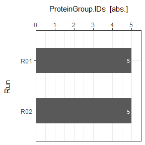

```r
ID_Barplots[["DIA-NN"]]
```

### Summary

As a visual summary a boxplot can be generated with `plot_ID_boxplot`.

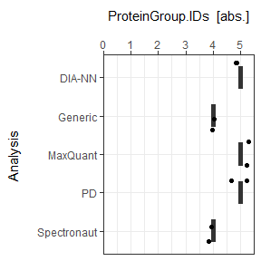

```r
plot_ID_boxplot(input_list = ID_Reports, level = "ProteinGroup.IDs")
```

# Data Completeness

## Report

Data Completeness can be determined with `get_DC_Report` for absolute numbers or in percentage.

```r
DC_Reports <- get_DC_Report(input_list = files, metric = "absolute")
DC_Reports_perc <- get_DC_Report(input_list = files, metric = "percentage")
```

For each analysis a DC Report is generated and stored in a list. Each DC Report entry can be easily accessed:

```r
flextable::flextable(DC_Reports[["DIA-NN"]])
```

| Analysis | Nr.Missing.Values | Precursor.IDs | Peptide.IDs | Protein.IDs | ProteinGroup.IDs | Profile |
| --- | --- | --- | --- | --- | --- | --- |
| DIA-NN | 1 | 0 | 0 | 4 | 2 | unique |
| DIA-NN | 0 | 5 | 5 | 3 | 4 | complete |

## Plot

### Individual

#### Absolute

Each DC Report can be plotted with `plot_DC_barplot` from precursor- to proteingroup-level. The generated barplots are stored in a list.

```r
DC_Barplots <- plot_DC_barplot(input_list = DC_Reports, level = "ProteinGroup.IDs", label = "absolute")
```

The individual barplots can be easily accessed:

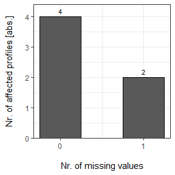

```r
DC_Barplots[["DIA-NN"]]
```

#### Percentage

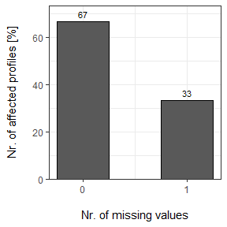

```r
plot_DC_barplot(input_list = DC_Reports_perc, level = "ProteinGroup.IDs", label = "percentage")[["DIA-NN"]]
```

### Summary

As a visual summary a stacked barplot can be generated with `plot_DC_stacked_barplot`.

#### Absolute

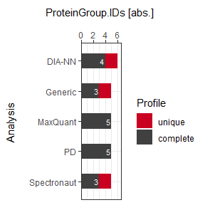

```r
plot_DC_stacked_barplot(input_list = DC_Reports, level = "ProteinGroup.IDs", label = "absolute")
```

#### Percentage

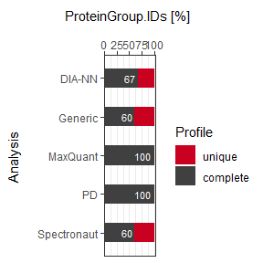

```r
plot_DC_stacked_barplot(input_list = DC_Reports_perc, level = "ProteinGroup.IDs", label = "percentage")
```

# Missed Cleavages

## Report

A report for Missed Cleavages can be generated with `get_MC_Report` for absolute numbers or in percentage.

```r
MC_Reports <- get_MC_Report(input_list = files, metric = "absolute")
MC_Reports_perc <- get_MC_Report(input_list = files, metric = "percentage")
```

For each analysis a MC Report is generated and stored in a list. Each MC Report entry can be easily accessed:

```r
flextable::flextable(MC_Reports[["Spectronaut"]])
```

| Analysis | Missed.Cleavage | mc_count |
| --- | --- | --- |
| Spectronaut | 0 | 1 |
| Spectronaut | 1 | 1 |
| Spectronaut | 2 | 1 |
| Spectronaut | 3 | 1 |

## Plot

### Individual

#### Absolute

```r
MC_Barplots <- plot_MC_barplot(input_list = MC_Reports, label = "absolute")
```

The individual barplots can be easily accessed:

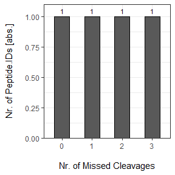

```r
MC_Barplots[["Spectronaut"]]
```

#### Percentage

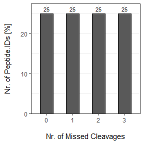

```r
plot_MC_barplot(input_list = MC_Reports_perc, label = "percentage")[["Spectronaut"]]
```

### Summary

As a visual summary a stacked barplot can be generated with `plot_MC_stacked_barplot`.

#### Absolute

[figure not shown]

```r
plot_MC_stacked_barplot(input_list = MC_Reports, label = "absolute")
```

#### Percentage

[figure not shown]

```r
plot_MC_stacked_barplot(input_list = MC_Reports_perc, label = "percentage")
```

# Retention Time Precision

## Preparation

The coefficient of variation (CV) can be calculated with `get_CV_RT`. Only complete profiles are used.

```r
CV_RT <- get_CV_RT(input_list = files)
```

## Plot

As a visual summary a density plot for all analyses can be accessed via `plot_CV_density`.

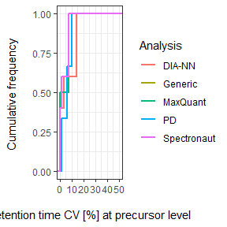

```r
plot_CV_density(input_list = CV_RT, cv_col = "RT")
```

# Quantitative Precision

## Peptide-level

### Preparation

The CV can be calculated with `get_CV_LFQ_pep`. Only complete profiles are used.

```r
CV_LFQ_Pep <- get_CV_LFQ_pep(input_list = files)
```

```
#> For DIA-NN no quantitative LFQ data on peptide-level.
#> For PD no quantitative LFQ data on peptide-level.
```

### Plot

As a visual summary a density plot for all analyses can be accessed via `plot_CV_density`.

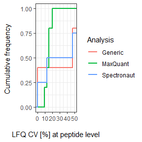

```r
plot_CV_density(input_list = CV_LFQ_Pep, cv_col = "Pep_quant")
```

## Proteingroup-level

### Preparation

The CV can be calculated with `get_CV_LFQ_pg`. Only complete profiles are used.

```r
CV_LFQ_PG <- get_CV_LFQ_pg(input_list = files)
```

```
#> For PD no quantitative LFQ data on proteingroup-level.
```

### Plot

As a visual summary a density plot for all analyses can be accessed via `plot_CV_density`.

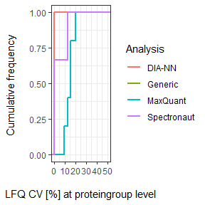

```r
plot_CV_density(input_list = CV_LFQ_PG, cv_col = "PG_quant")
```

# Upset Plot

Common identifications and intersections between analyses can be highlighted.

## Preparation

Use `get_Upset_list` to prepare for Upset plotting.

```r
Upset_prepared <- get_Upset_list(input_list = files, level = "ProteinGroup.IDs")
```

## Plot

The Upset plot can be generated with `plot_Upset`.

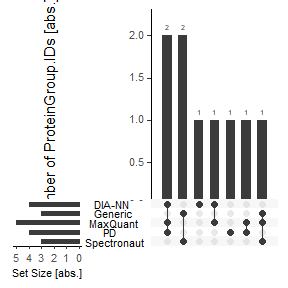

```r
plot_Upset(input_list = Upset_prepared, label = "ProteinGroup.IDs")
```

## Inter-software Comparison - flowTraceR

Functions of the package flowTraceR are incorporated in mpwR for inter-software comparisons. Software outputs are standardized and easily comparable.

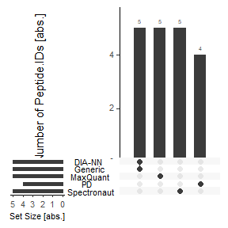

```r
get_Upset_list(input_list = files, level = "Peptide.IDs") %>% #prepare Upset
  plot_Upset(label = "Peptide.IDs") #plot
```

```
#> flowTraceR not available for generic input. No conversion applied for position 5 in input_list.
```

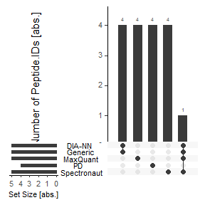

```r
get_Upset_list(input_list = files, level = "Peptide.IDs", flowTraceR = TRUE) %>% #prepare Upset
  plot_Upset(label = "Peptide.IDs") #plot
```

# Summary

**mpwR** offers functions to summarize the downstream analysis.

## Report

A summary report can be generated with `get_summary_Report`.

```r
Summary_Report <- get_summary_Report(input_list = files)
```

## Plot

As a visual summary a radar chart for all analyses can be accessed via `plot_radarchart`.

### Overview

```r
plot_radarchart(input_df = Summary_Report)
```

[output not shown]

### Details

To highlight individual categories, the generated summary report can be easily adjusted and used for plotting.

```r
#Focus on Data Completeness
Summary_Report %>%
  dplyr::select(Analysis, contains("Full")) %>% #Analysis column and at least one category column is required
  plot_radarchart()
```

[output not shown]